# Categorical Data

```r
#..count..: special variable to represent frequency
p1 <- ggplot(data=diamonds, aes(x=cut, y=..count..))
p2 <- ggplot(data=diamonds, aes(x=cut, y=..count../sum(..count..)))
```

4. R code: _______________________________

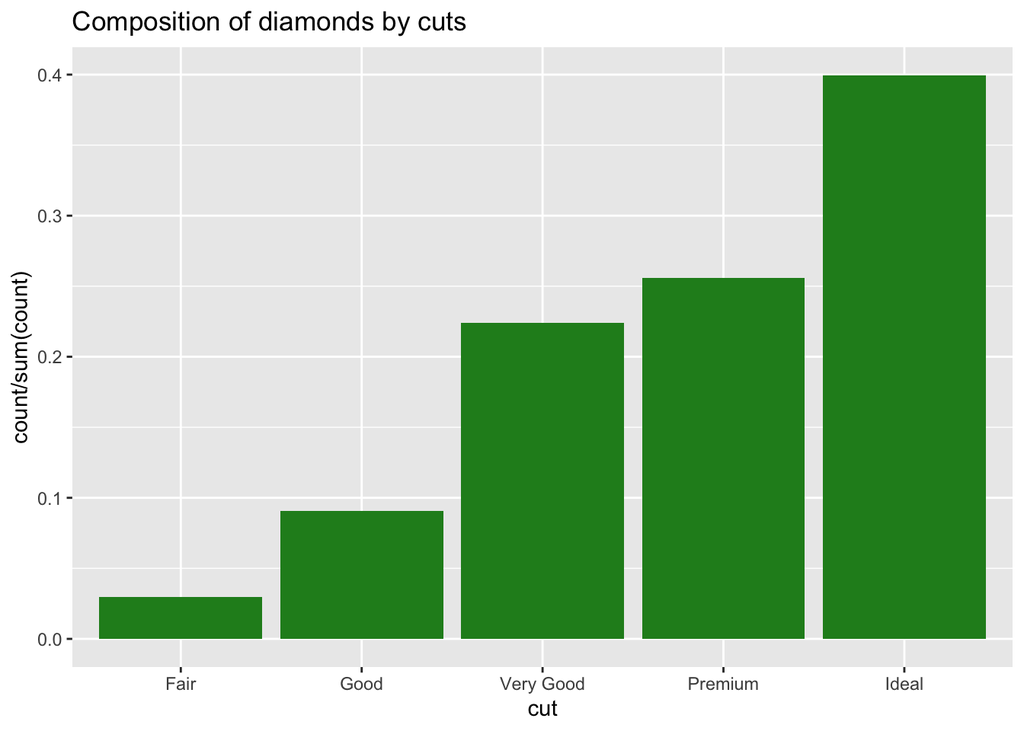

5. R code: _______________________________

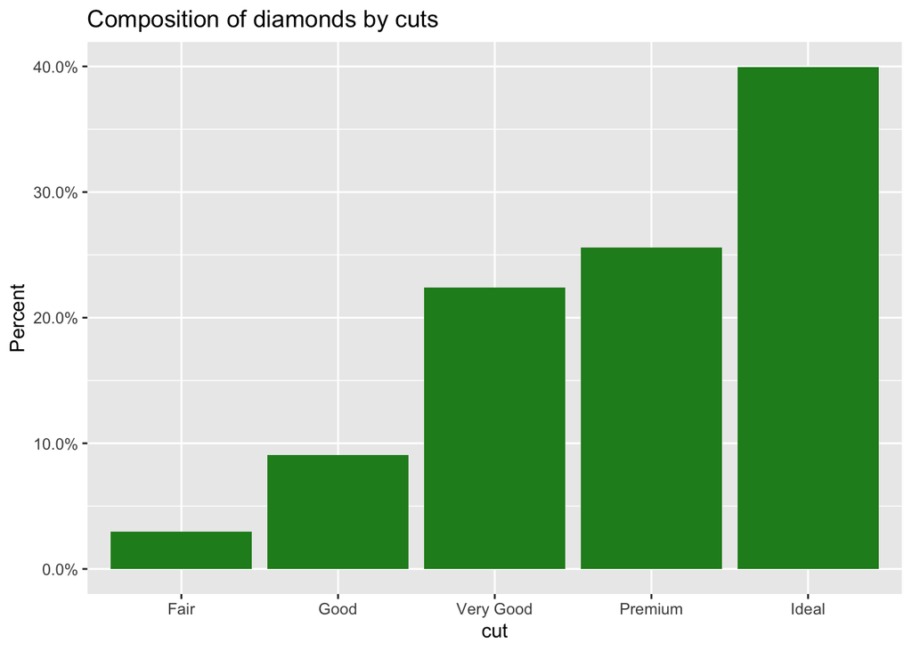

6. R code: _______________________________

```
        cut percent
1      Fair     3.0
2      Good     9.0
3 Very Good    22.4
4   Premium    25.6
5     Ideal    40.0
```

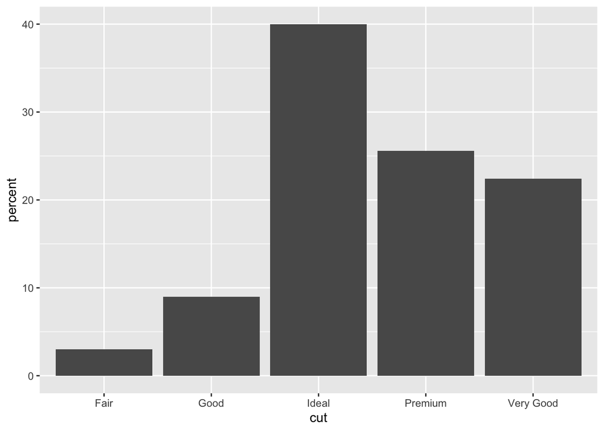

```r
p3 <- ggplot(data=cut.percent, aes(x=cut, y=percent))
```

7. R code: _______________________________

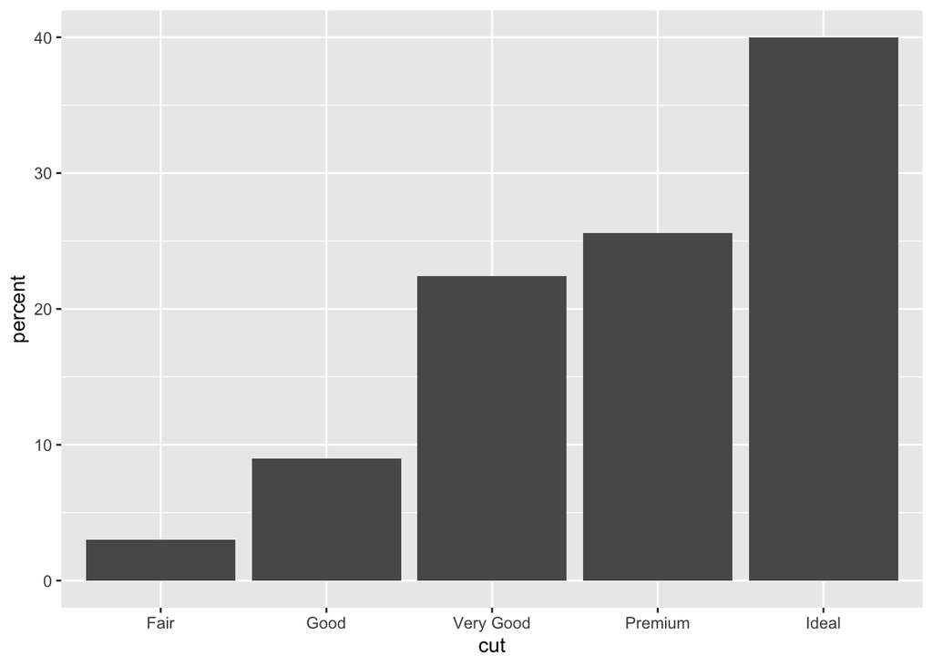

```r
# Need to rerun this once you change the factor levels (can't use p3)
ggplot(data=cut.percent, aes(x=cut, y=percent))+geom_bar(stat="identity")
```

8. Labeling bars: what is the suitable geom to add here?

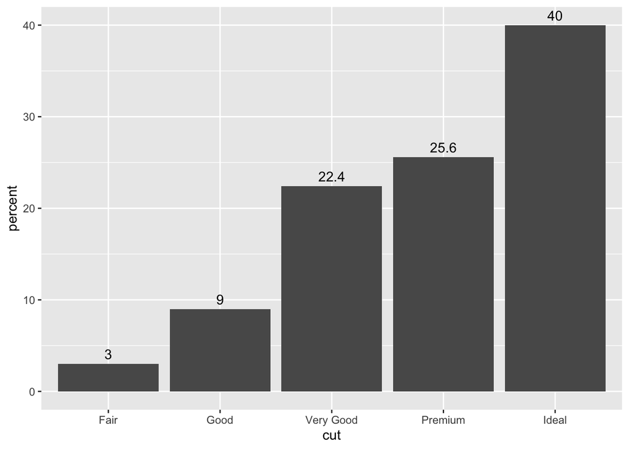

9. R code:___________

Help: use `coord_flip`

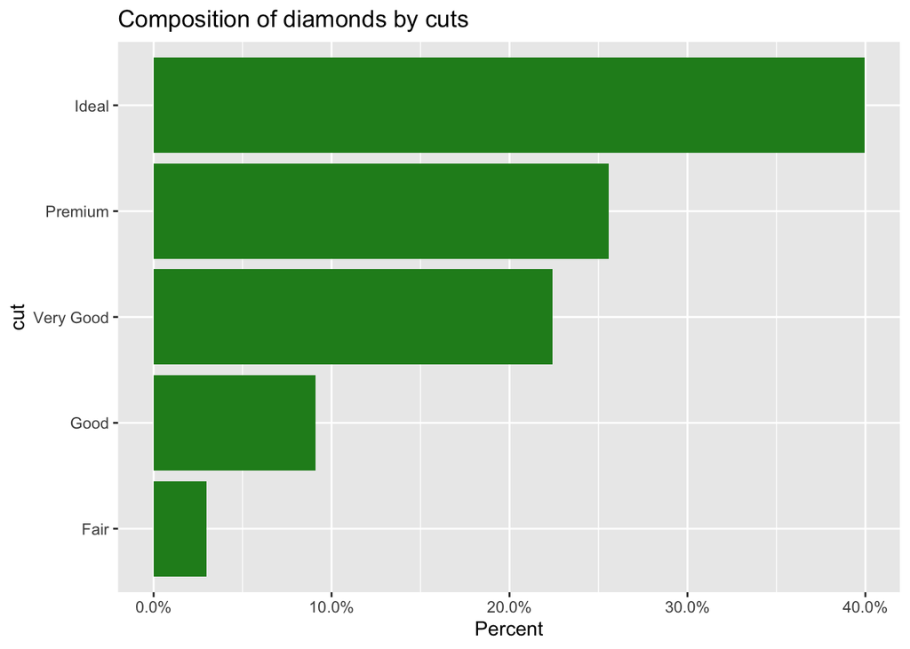

10. R Code:____________

```
        cut percent  prop
1      Fair     3.0 0.030
2      Good     9.0 0.090
3 Very Good    22.4 0.224
4   Premium    25.6 0.256
5     Ideal    40.0 0.400
```

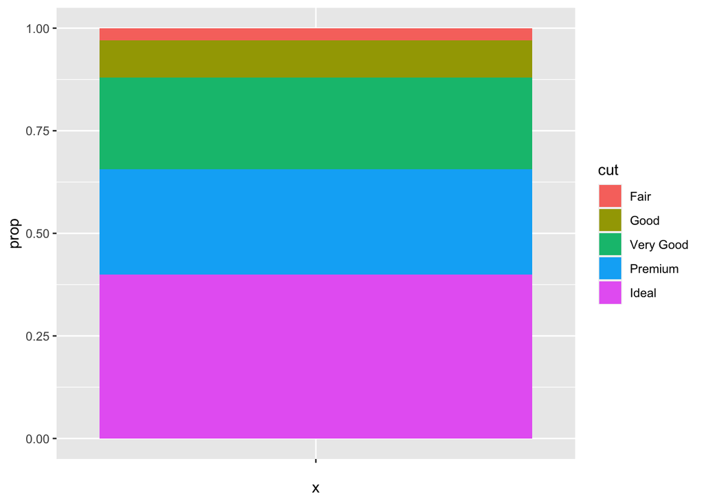

```r
ggplot(data=cut.prop, aes(x="", y=prop, fill=cut))+geom_bar(stat="identity", width=1)
```

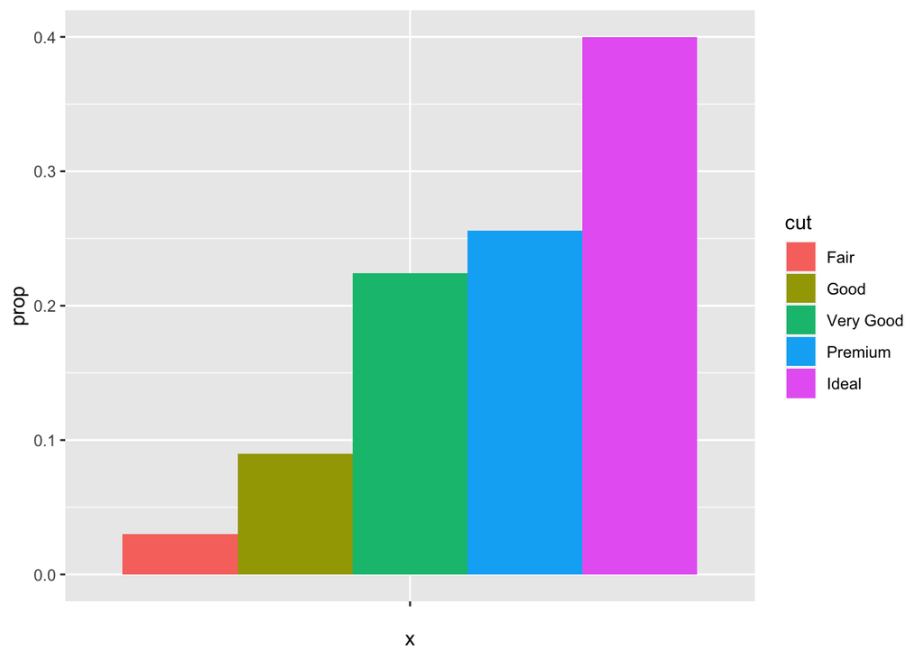

```r
ggplot(data=cut.prop, aes(x="", y=prop, fill=cut))+geom_bar(stat="identity", width=1, position = "dodge")
```

11. R Code:____________

Pie charts are controversial in statistics.

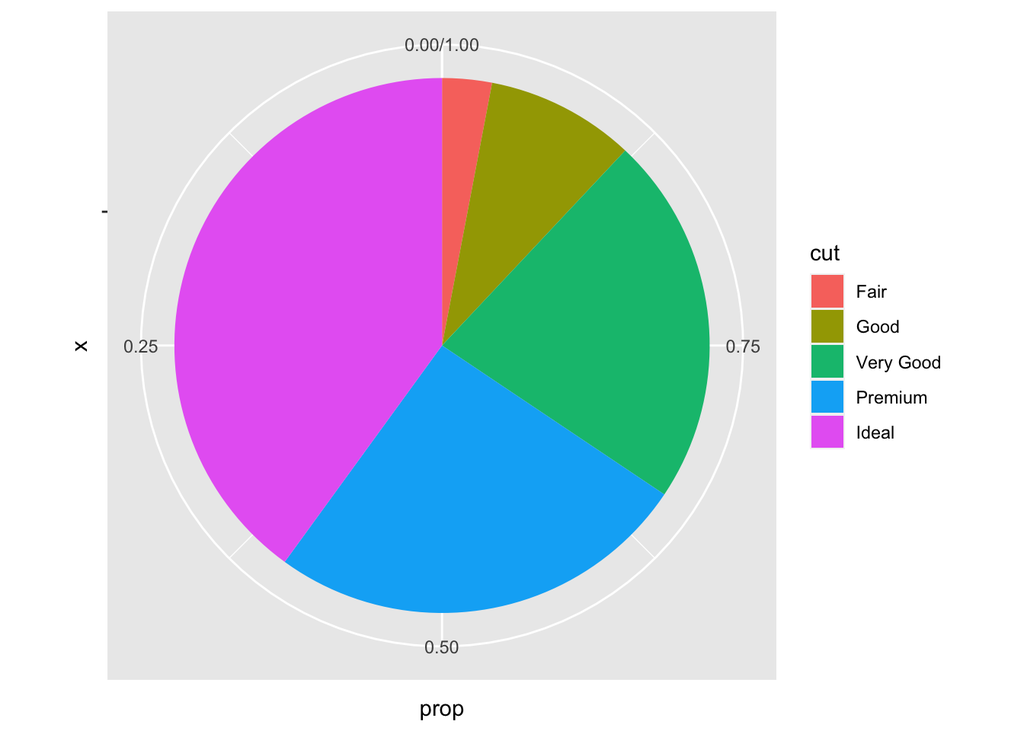

Some extra work is needed to make the pie chart appealing to human eye.

## Bi-variate

### Stacked bar chart

**Encoding by colour**

Position: `stack`

```r
b1 <- ggplot(data=diamonds, aes(x=cut, fill=color))
```

12: R code:___________

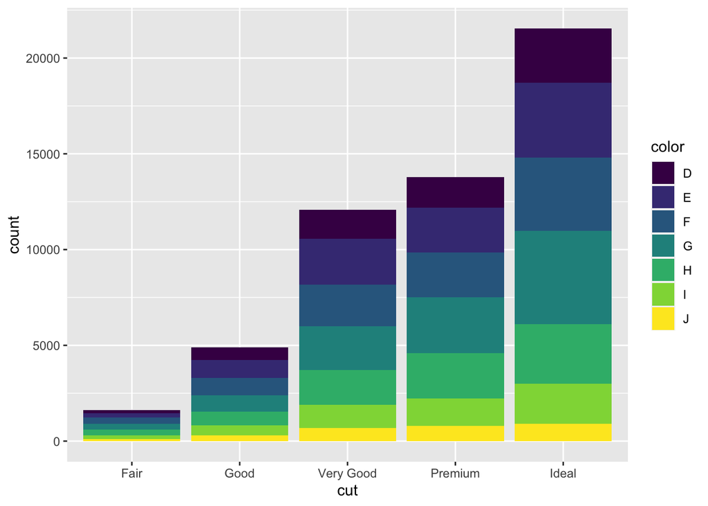

### Grouped bar chart

**Encoding by colour**

Position: `dodge`

13: R code:___________

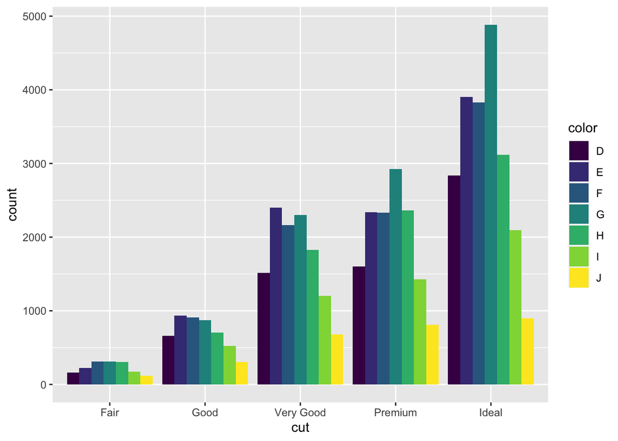

### Segmented bar chart

Position: `fill`

14: R code:___________

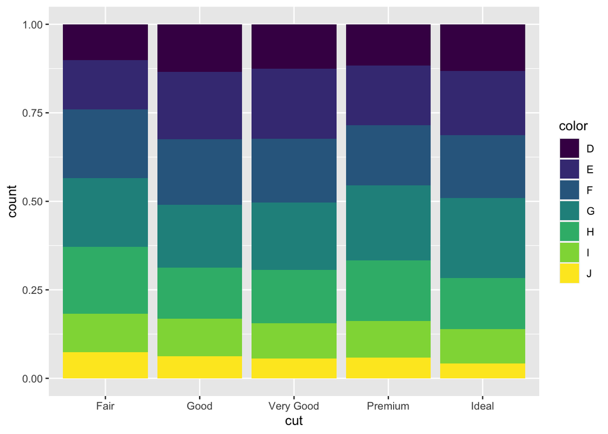

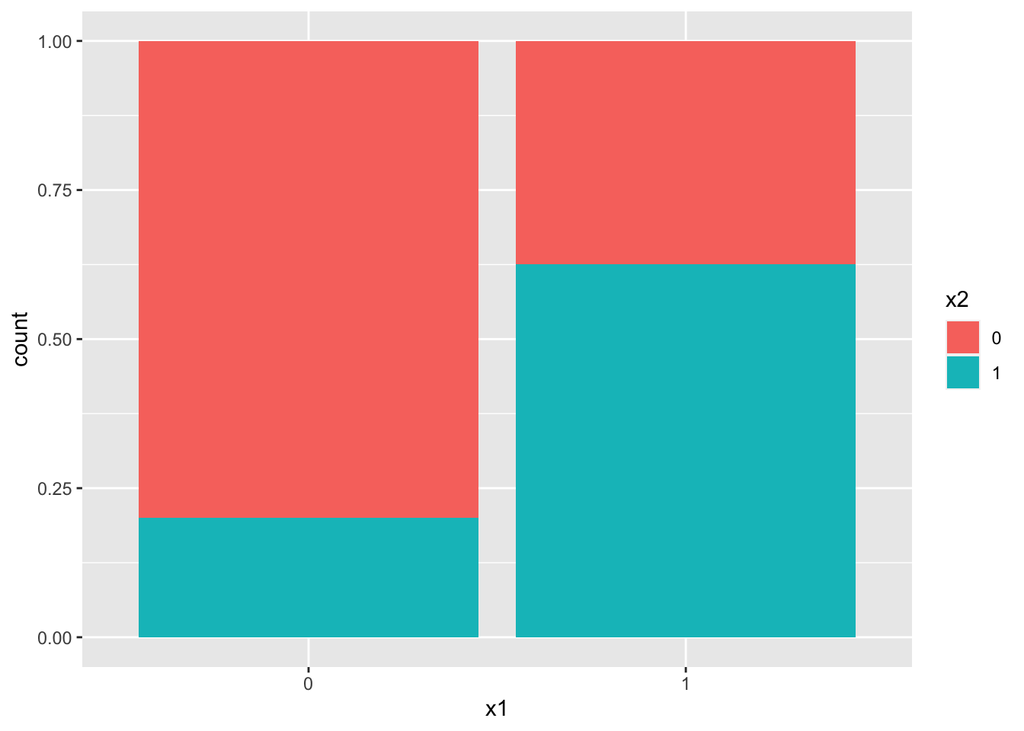

15: Rcode:_______________

**Encoding by position**

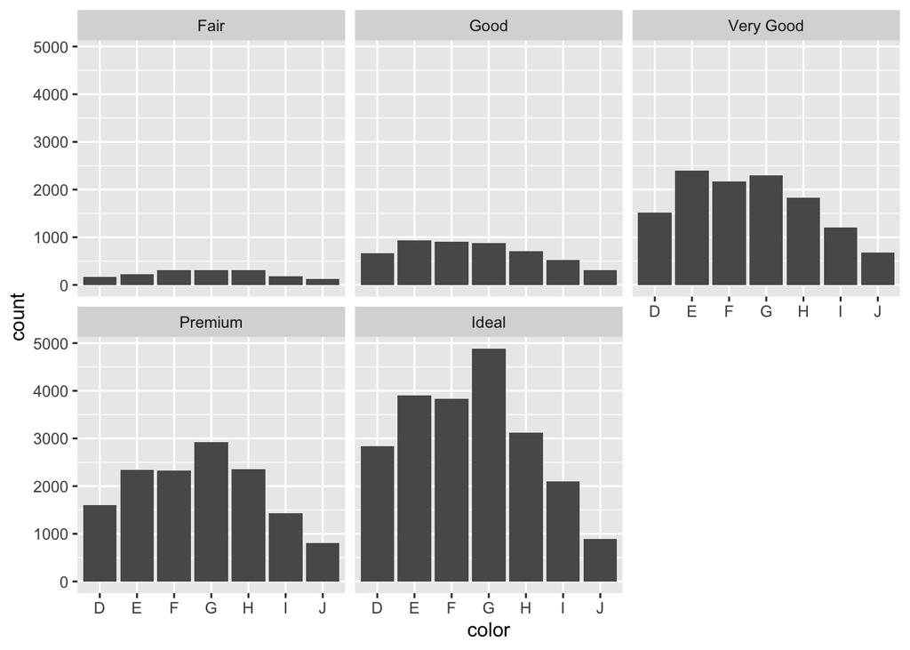

```r
ggplot(data=diamonds, aes(x=color))+geom_bar()+facet_wrap(~cut)
```

## Categorical vs Quantitative

### Cleveland dot chart

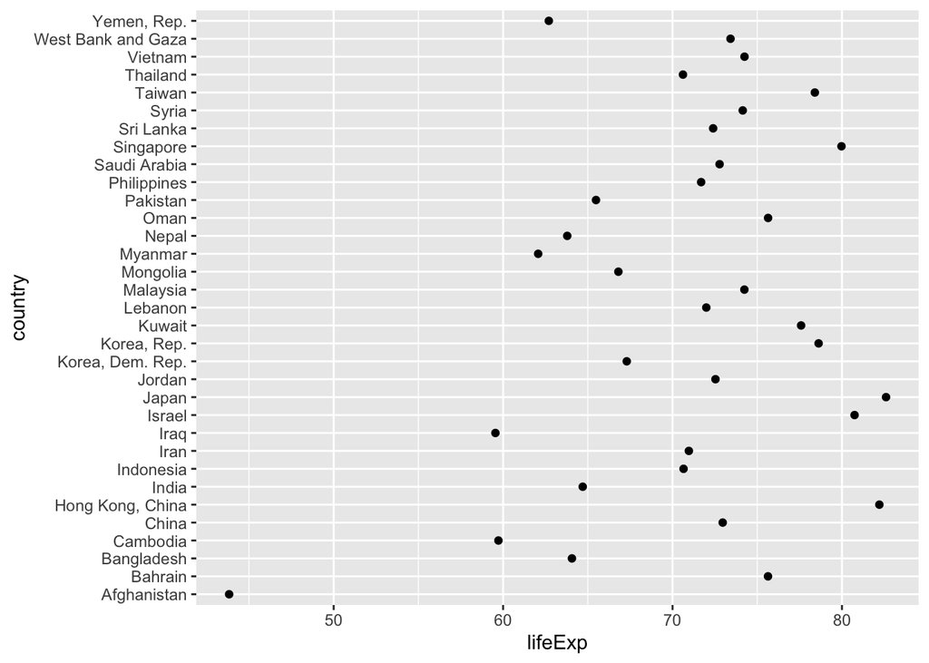

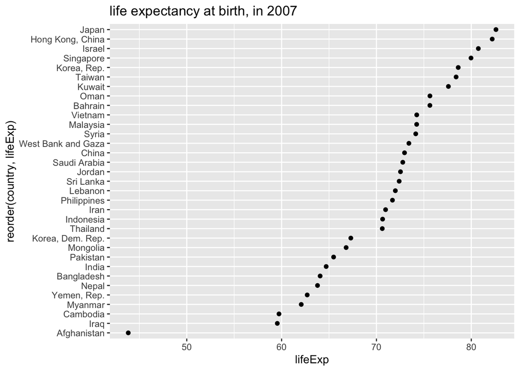

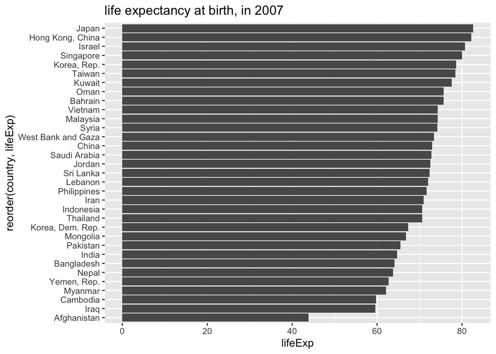

### Heat map

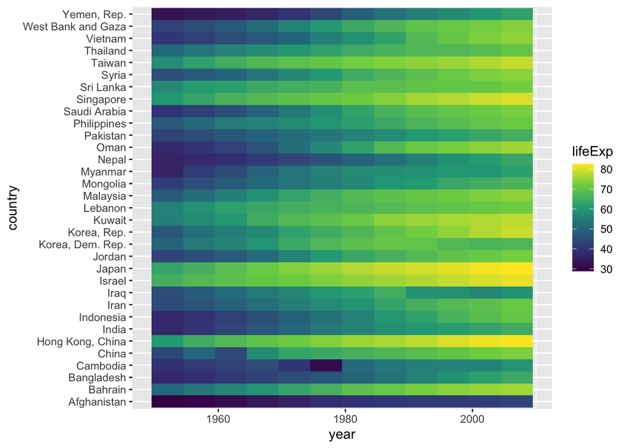

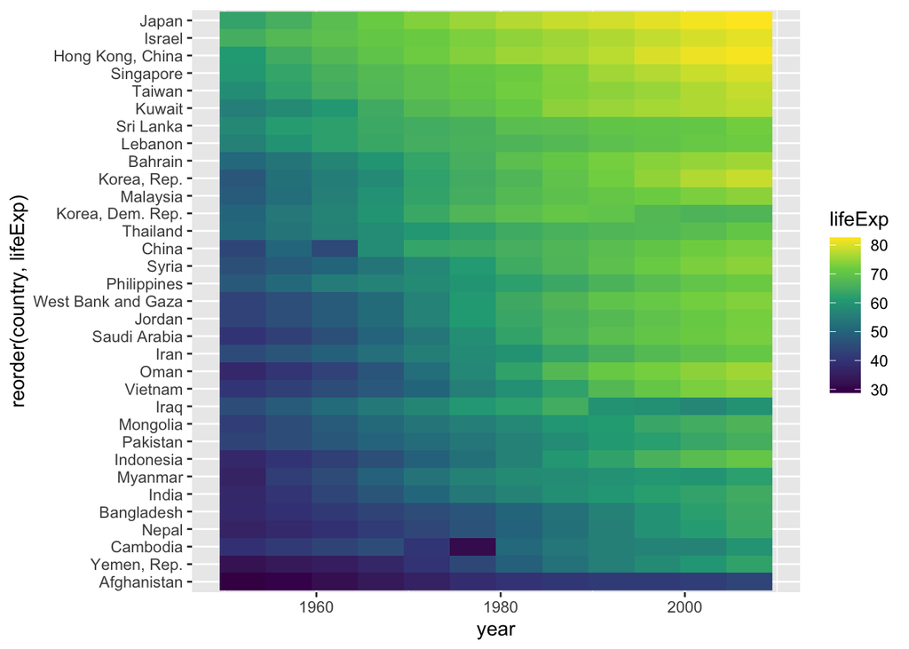

### Summary statistics

16. R code:___________________

```
# A tibble: 5 x 2
  cut       mean_carat
  <ord>          <dbl>
1 Fair           1.05
2 Good           0.849
3 Very Good      0.806
4 Premium        0.892
5 Ideal          0.703
```

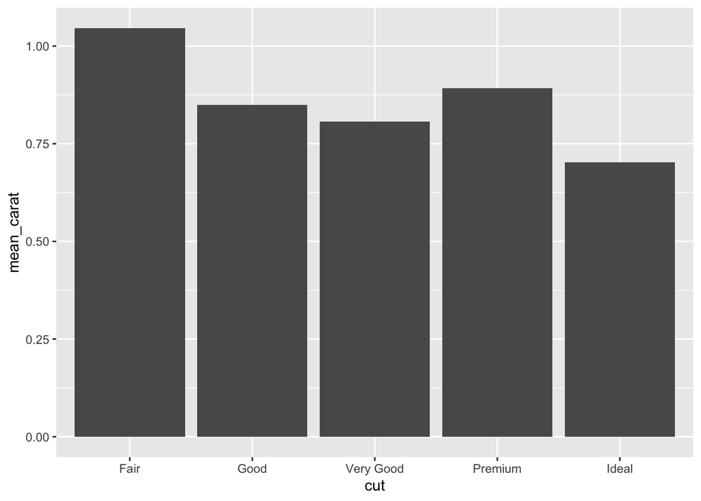

### Plotting summary statistics: `stat_summary`

17. R code:___________________

`mean_se`: mean and standard error

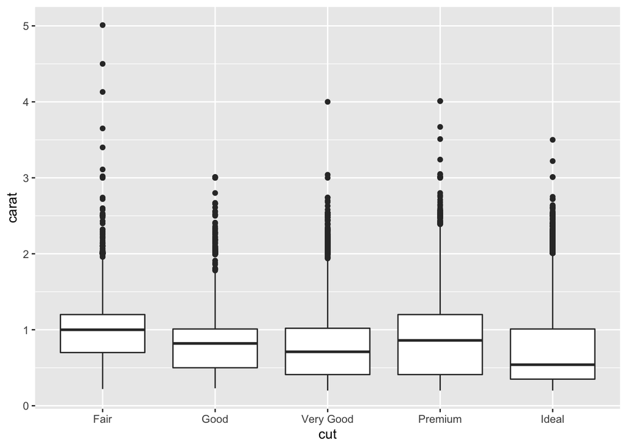

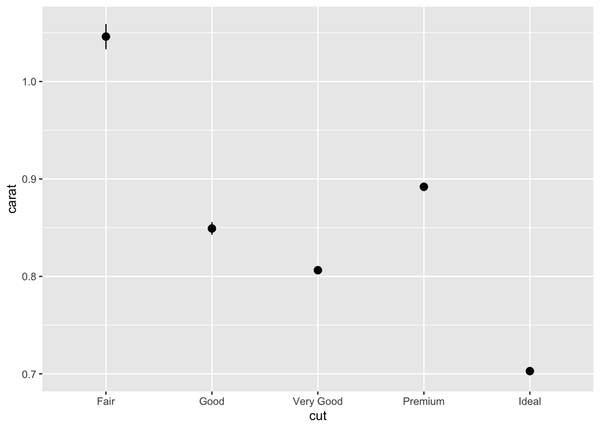

```r
g1 <- ggplot(diamonds, aes(x = cut, y = carat))
```

18. R code:___________________

`mean_cl_normal`: 95 per cent confidence interval assuming normality. (Use `library(Hmisc)`)

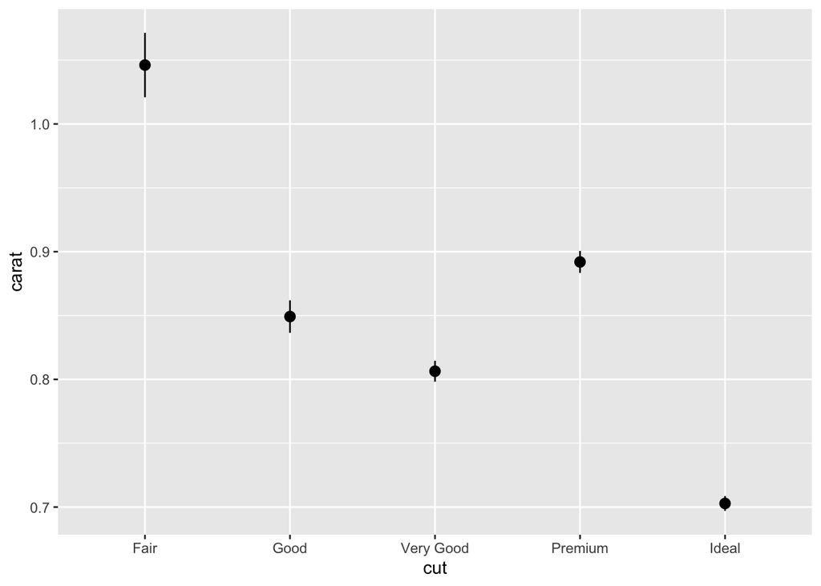

19. R code:___________________

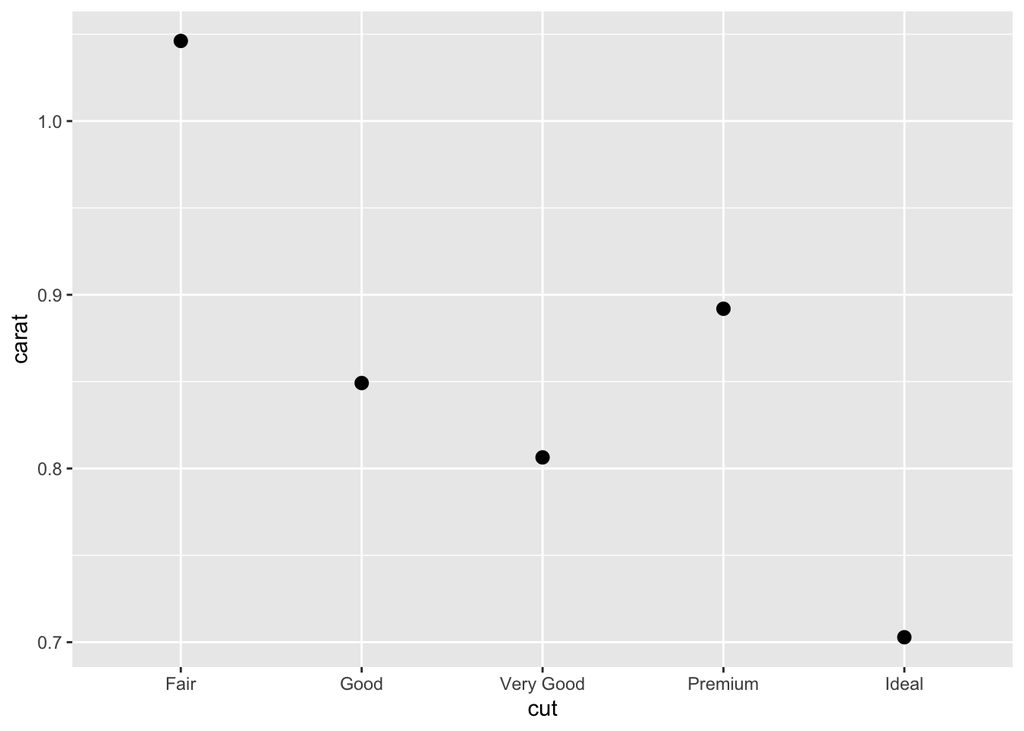

20. R code:___________________

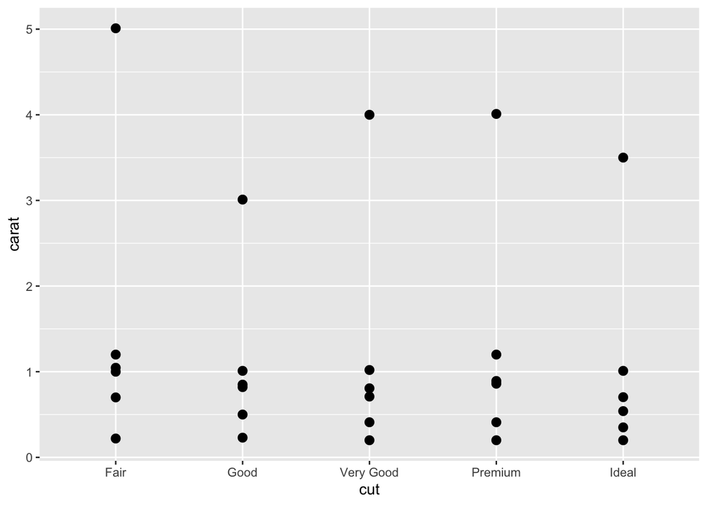

21. R code:___________________

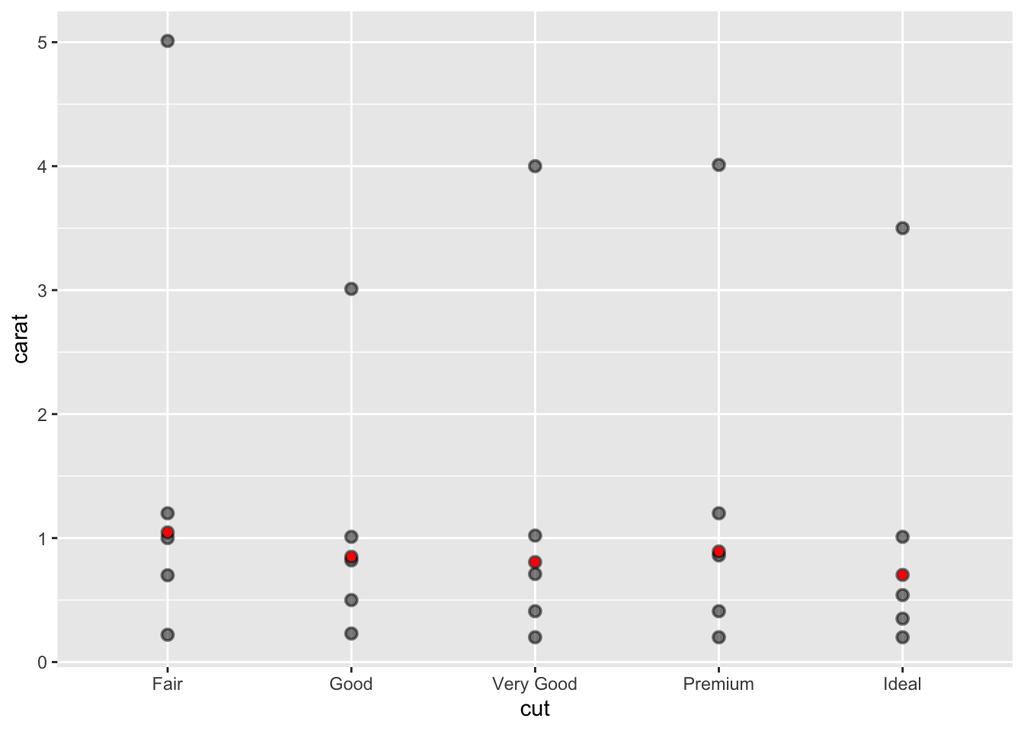

22. R code:___________________

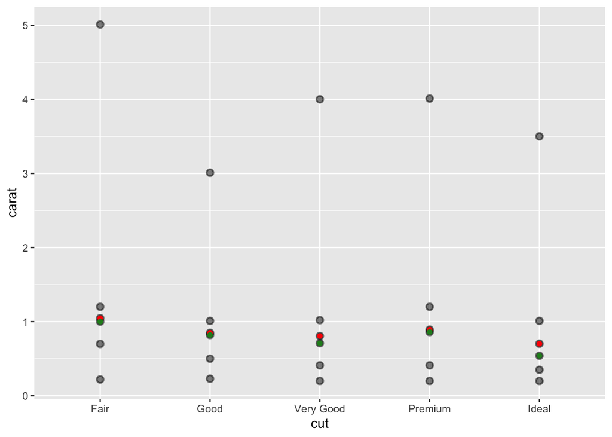

23. R code:___________________

`mean_cl_boot`: Bootstrap confidence interval (95%)

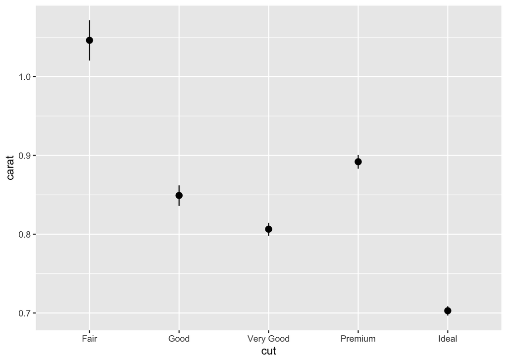

24. R code:___________________

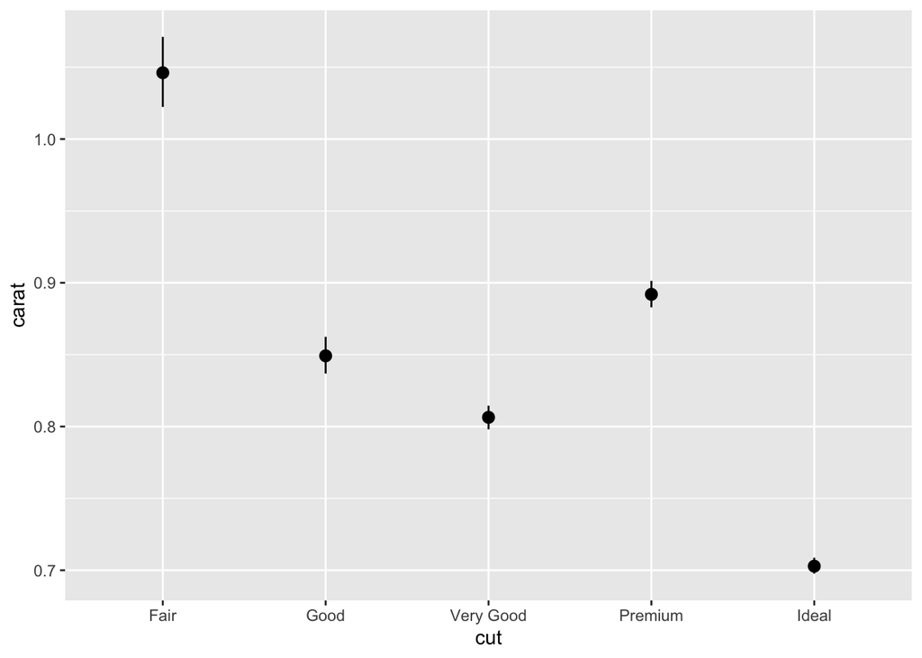